# 0625 practice

Soomin Park

2019 6 25

#### 어느 대학교에서 대중교통을 이용하여 등교하는 학생의 비율을 알아보기 위하여 이 학교 학생 중 n 명을 임의 추출하여 조사한 결과 50%의 학생이 대중교통을 이용하여 등교하는 것으로 나타났다. 이 결과를 이용하여 이 대학교 전체 학생 중에서 대중교통을 이용하여 등교하는 학생의 비율 p에 대한 신뢰도 95%의 신뢰 구간을 구하시오

```r
# size = n, p_hat = 0.5, p에 대한 95 % 신뢰구간 (alpha = 0.05)
p_h <- 0.5  ; alpha <- 0.05
# Z = (p_hat-p_0)/sqrt(p_0 * (1-p_0)/n)
# P-value (CI) = 0.95
# qnorm (0.025), qnorm (0.975) ->  -1.96 < Z < 1.96
# n 은 미지수 상태, 모비율인 p_0 는 알 수 없으므로 p_0 = p_hat 으로 근사값을 대체

# 결과 식:  p_h + c.l * sqrt(p_h*(1-p_h)/n) < p_0 < p_h + c.u * sqrt(p_h*(1-p_h)/n)
# 임의로 n = 30 이라 주었을 떄
n <- 30
p_l <-  0.5 - 1.96 * sqrt(0.5*0.5/n)
p_u <-  0.5 + 1.96 * sqrt(0.5*0.5/n)

# 결론
cat(paste(" 표본 크기 n = 30, 표본 비율 p_hat = 0.5 일 때, 모비율 p에 대한 신뢰도 95%의 구간은 \n",
      round(p_l , 3),  "< p_0 <",round( p_u, 3) ,"이다"))
```

```
##  표본 크기 n = 30, 표본 비율 p_hat = 0.5 일 때, 모비율 p에 대한 신뢰도 95%의 구간은
##  0.321 < p_0 < 0.679 이다
```

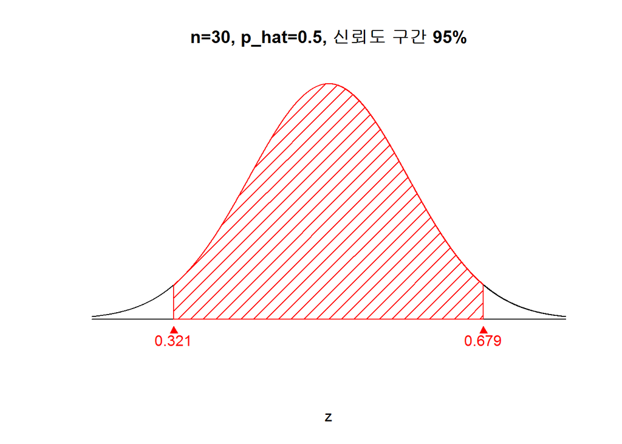

```r
# 그래프
z <- seq(-3, 3, by=0.001)
z.p <- dnorm(z)

plot(z, z.p, axes=F, type="l",
     main="n=30, p_hat=0.5, 신뢰도 구간 95%", ylab="", ylim=c(-0.04, 0.4))
lines(c(-3, 3), c(0, 0))

points(-1.96, -0.02, pch=17, col="red")
text(-1.96, -0.035, round(p_l, 3), col="red")
points(1.96, -0.02, pch=17, col="red")
text(1.96, -0.035, round(p_u, 3), col="red")

s <- seq(-1.96, 1.96, by=0.001)
s.z <- dnorm(s, mean=0, sd=1)
s <- c(-1.96, s, 1.96)
s.z <- c(0, s.z, 0)

polygon(s, s.z, density=10, col="red")
```